# Spatial Models

The goals of this lesson are to introduce how spatial dependence detected and modeled for uni- and multi-variate response variables. Although in this lesson we focus on spatial dependence the core concepts of how to detect and model a lack of independence in samples may be applied to dependence due to: time, relatedness, position on a genome, and many other study specific driver variables.

## Readings

- Crawley (2007) The R Book, pp. 778-785 on Generalized Least Squares models with spatially correlated errors
- Borcard et al. (2011) Numerical Ecology in R, pp. 228-238 on detecting spatial dependence.
- Pinheiro and Bates (2000) Mixed-Effects Models in S and S-PLUS, pp. 249-267 on Fitting Extended Linear Mdoels with gls
- https://beckmw.wordpress.com/2013/01/07/breaking-the-rules-with-spatial-correlation/

## Outline

- Spatial autocorrelation and induced spatial dependence
- Detecting a spatial signal
- Univariate modeling
- Multivariate modeling

## Spatial autocorrelation and induced spatial dependence

There are two general reasons why spatial dependence may exist in a response variable.

1. autocorrelation - the variable is spatially non-random due its own internal dynamics. In ecology this is sometimes referred to as a false gradient. An example of this is when offspring have limited dispersal from their natal site and therefore finding one organism increases the likelihood of finding another.
2. induced spatial dependence: the variable is not inherently spatially structured but the driving factors that it responds to are. In ecology this is sometimes referred to as a true gradient. An example of this phenomena would be if an organism’s physiology is driven by temperature, and if temperature is non-randomly spatially structured then the organism should also display non-random patterns of occurrence.

There is no statistical way to distinguish false from true gradients.

## Detecting a spatial signal

We are going to use data on the occurrence of Oribatid mites collected from 70 soil cores across a field to examine how to detect non-random spatial signals for both univariate and multi-variate response variables. Specifically, we will examine a vector of species richness (i.e., number of species in a site), and a matrix of species composition (i.e., a community abundance matrix):

```r
library(vegan)
library(nlme)
# Oribatid mite data. 70 soil cores collected by Daniel Borcard in 1989.
# See Borcard et al. (1992, 1994) for details.
data(mite)
data(mite.env)
data(mite.xy)
?mite
```

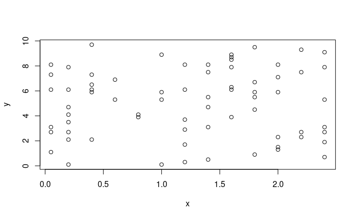

```r
plot(mite.xy)
```

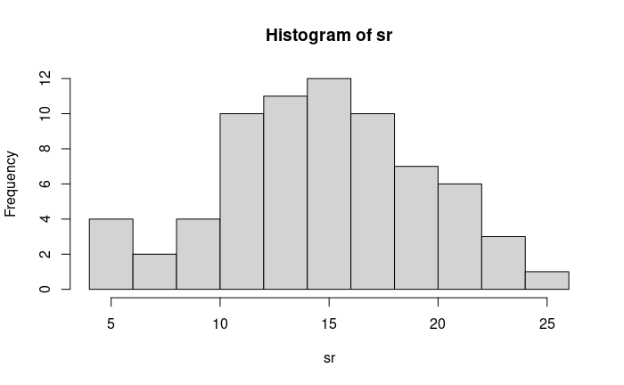

```r
sr <- rowSums(mite > 0)
hist(sr)
```

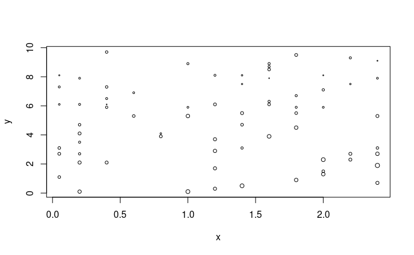

```r
plot(mite.xy, cex = sr/max(sr))
```

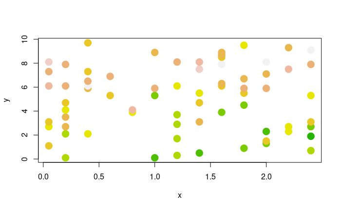

```r
col_brks <- hist(sr, plot=F)$breaks
col_indices <- as.numeric(cut(sr, col_brks))
cols <- rev(terrain.colors(length(col_brks)))
plot(mite.xy, cex=2, pch=19, col=cols[col_indices])
```

Visually it appears that low richness sites (i.e., brown circles) are more likely to be near other low richness sites - this indicates a pattern of spatial dependence. We can carry out some very simple analyses to examine if this relationship is stronger than we would expect under a null model of randomly shuffled spatial positions. Our test statistic in this context is the Pearson correlation coefficient between the difference in the response variable (i.e., richness) and the difference in spatial proximity.

```r
# calculate Euclidean distance between richness and spatial coordinates
sr_dist <- dist(sr)
xy_dist <- dist(mite.xy)
```

For interpretation purposes a rule of thumb is not to interpret distances great than 1/2 the maximum distance in the dataset. This is to avoid examining spatial patterns that are underlaid by only a few samples. At small to intermediate distances there are typically many more pairs of samples where as at the extreme ends of a sampling grid there are only two sets of samples (i.e., those that lie along the two diagonals corners from one another)

```r
max_dist <- max(xy_dist) / 2

# plot result
plot(xy_dist, sr_dist)
abline(lm(sr_dist ~ xy_dist), lwd=3, col='red')
```

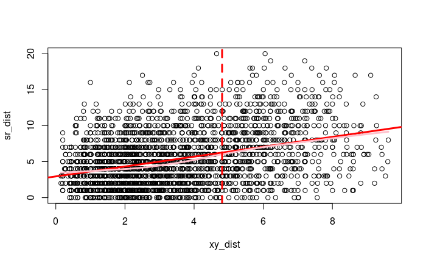

```r
lines(lowess(xy_dist, sr_dist), lwd=3, col='pink')
abline(v = max_dist, col='red', lwd=3, lty=2)
```

```r
# compute correlation
obs_cor <- cor(xy_dist, sr_dist)
obs_cor
```

```
[1] 0.366253
```

##### **Question**

Based on the graphic above does it appear that values of species richness are more similar or more different the further apart they are in space?

[Show answer]

```
The above graphic demonstrates that the greater the distance between two samples
the more different those samples are in their species richness. In other words,
values of species richness are displaying positive autocorrelation or a spatially
aggregated pattern.
```

##### **Question**

What would a random spatial signal look like on this graph?

[Show answer]

```
A flat line (i.e., a correlation close to zero).
```

We can better examine if our intuition is correct by randomizing the location of each sample and re-making our graphic and re-estimating the correlation coefficient.

```r
# randomize the rows of the spatial coordinates matrix
?sample
null_xy <- mite.xy[sample(nrow(mite.xy)), ]
null_dist <- dist(null_xy)

plot(null_dist, sr_dist)
abline(lm(sr_dist ~ null_dist), lwd=3, col='red')
```

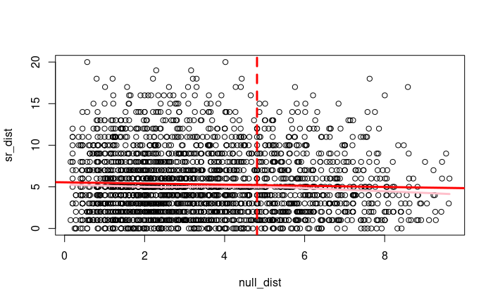

```r
lines(lowess(null_dist, sr_dist), lwd=3, col='pink')
abline(v = max_dist, col='red', lwd=3, lty=2)
```

```r
# compute null correlation
null_cor <- cor(null_dist, sr_dist)
null_cor
```

```
[1] -0.03739482
```

That does look pretty flat for this randomized spatial location. We can develop a permutation test if we carry out this same procedure many times to develop a null distribution of correlation values. Then we can ask if our observed value of r = 0.37 is larger than we would expect simply due to random chance.

Here we will demonstrate how to make make this on your own and how to carry it out using the `vegan` function `mantel`

```r
# carry out a permutation test for significance:
nperm <- 999
null_cor <- NULL
# now we'll want to generate 999 random null estimates of r
for (i in 1:nperm) {
    # shuffle the rows of the spatial coordinates
    null_xy <- mite.xy[sample(nrow(mite.xy)), ]
    # correlation between the shuffled spatial coordinates and sr_dist
    null_cor[i] <- cor(dist(null_xy), sr_dist)
}

# to get our 1000th possible outcome we'll consider that the observed
# correlation value is a 'possibility' we should consider in the null distribution:
null_cor <- c(null_cor, obs_cor)

# compute the p-value which is simply the proportion of times we observed a
# value equal to or greater than the observed correlation. We will learn that a
# value equal to or as large as the observed value only occurs once out of the
# 1000 possiblities considered so p = 0.001
sum(null_cor >= obs_cor) / (nperm  + 1)
```

```
[1] 0.001
```

```r
# carry out the same analysis using the function mantel()
?mantel
sr_mantel <- mantel(xy_dist, sr_dist)
sr_mantel
```

```
Mantel statistic based on Pearson's product-moment correlation

Call:
mantel(xdis = xy_dist, ydis = sr_dist)

Mantel statistic r: 0.3663
      Significance: 0.001

Upper quantiles of permutations (null model):
   90%    95%  97.5%    99%
0.0511 0.0670 0.0820 0.0926
Permutation: free
Number of permutations: 999
```

We can see that the estimated p-value is 0.001 (from both our hand made algorithm and the `vegan::mantel` function). This indicates that there is a statistically significant pattern of positive spatial autocorrelation which fits our intuitive interpretation we developed graphically.

Now let’s examine the distribution of null correlation values to better understand how the p-value was computed.

```r
# compare the two approaches graphically using stacked boxplots
boxplot(list(null_cor, sr_mantel$perm), horizontal = F, boxwex = 0.5,
        names = c('hand-made algo', 'vegan::mantel'), ylab='Correlation',
        ylim = range(null_cor))
abline(h=obs_cor, col='red')
```

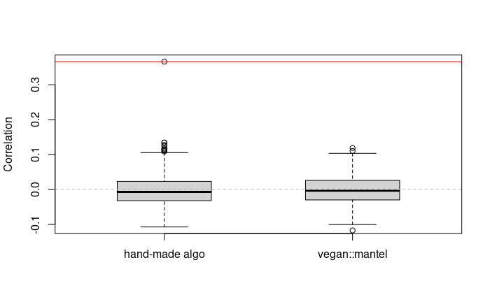

```r
abline(h=0, lty = 2, col = 'grey')
```

##### **Question**

What would a significant negative correlation indicate?

[Show answer]

```
That the spatial pattern is uniform (rather than random or aggregated). This
might occur for example when individuals repel one another due to competition.
```

This preliminary analysis suggests that there is a significant relationship between the spatial distance that two points are separated and the difference in species richness of the points.

Let’s take a similar approach but using a multivariate response variable in this case a site-by-species community matrix. It is difficult to visualize from a birds-eye view changes in a multivariate response variable because you would need to layer a different map for each column in the matrix. That still might not really provide you with a reduction of information that is useful for making an inference. Here we will first reduce the information in the response matrix using a non-metric multi-dimensional scaling ordination procedure. For simplicity of visualization we’ll just map the 1st axis on to the spatial location of the samples.

```r
mite_mds <- metaMDS(mite)
```

```
Square root transformation
Wisconsin double standardization
*** Best solution repeated 1 times
```

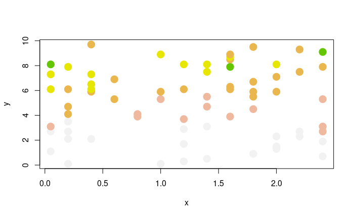

```r
mds_axs1 <- mite_mds$points[ , 1]

col_brks <- hist(mds_axs1, plot=F)$breaks
col_indices <- as.numeric(cut(mds_axs1, col_brks))
cols <- rev(terrain.colors(length(col_brks)))
plot(mite.xy, cex=2, pch=19, col=cols[col_indices])
```

As with richness there is a pretty clear spatial pattern from south to north. In this case though it appears that the signal is even stronger than in the species richness example as clear bands appear.

Let’s now undertake a more quantitative approach and estimate the degree of autocorrelation.

```r
## compute bray curtis distance for the community matrix
## note when working with species-richness we just used Euclidean distance
comm_dist <- vegdist(mite)
plot(xy_dist, comm_dist)
abline(lm(comm_dist ~ xy_dist), lwd=3, col='red')
```

```r
lines(lowess(xy_dist, comm_dist), lwd=3, col='pink')
lines(lowess(xy_dist, comm_dist, f=0.1), lwd=3, col='blue')
```

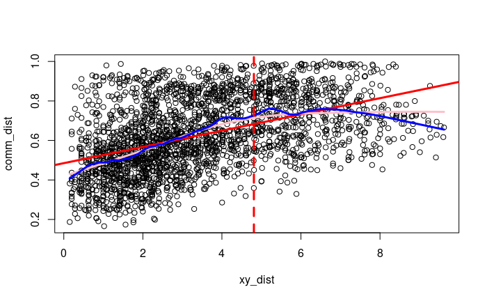

```r
abline(v = max_dist, col='red', lwd=3, lty=2)
```

```r
comm_mantel <- mantel(xy_dist, comm_dist)
comm_mantel
```

```
Mantel statistic based on Pearson's product-moment correlation

Call:
mantel(xdis = xy_dist, ydis = comm_dist)

Mantel statistic r: 0.4589
      Significance: 0.001

Upper quantiles of permutations (null model):
   90%    95%  97.5%    99%
0.0488 0.0618 0.0749 0.0910
Permutation: free
Number of permutations: 999
```

Species composition also appears to display positive spatial auto-correlation and it is a little stronger than species richness.

The previous plots included both the linear regression model which is what the mantel analysis is based upon and the lowess smoother line. The smoother can help to identify if the relationship is non-linear and how the strength of the relationship varies with spatial distance.

Note that the estimated correlation coefficients that we have been using as our test statistic use all of the distance classes including distances that are greater than 1/2 the max distance which we noted above is generally frowned upon. Notice in the above plot for `comm_dist` that the slope of the lowess lines is steeper than the linear regression line - this indicates a signal of spatial dependence or a non-linear change in the degree of spatial autocorrelation as a function of distance

To develop a more nuanced understanding of the pattern of spatial autocorrelation we can bin distances into bins and then compute **r** at each distance class to build a correlogram.

```r
sr_corlog <- mantel.correlog(sr_dist, xy_dist)
comm_corlog <- mantel.correlog(comm_dist, xy_dist)
sr_corlog
```

```
Mantel Correlogram Analysis

Call:

mantel.correlog(D.eco = sr_dist, D.geo = xy_dist)

        class.index     n.dist Mantel.cor Pr(Mantel) Pr(corrected)
D.cl.1     0.514182 358.000000   0.102654      0.001         0.001 ***
D.cl.2     1.242546 650.000000   0.135647      0.001         0.002 **
D.cl.3     1.970910 796.000000   0.139241      0.001         0.003 **
D.cl.4     2.699274 696.000000   0.077577      0.001         0.004 **
D.cl.5     3.427638 500.000000   0.032271      0.066         0.066 .
D.cl.6     4.156002 468.000000  -0.043035      0.019         0.038 *
D.cl.7     4.884366 364.000000  -0.055028      0.002         0.007 **
D.cl.8     5.612730 326.000000         NA         NA            NA
D.cl.9     6.341094 260.000000         NA         NA            NA
D.cl.10    7.069458 184.000000         NA         NA            NA
D.cl.11    7.797822 130.000000         NA         NA            NA
D.cl.12    8.526186  66.000000         NA         NA            NA
D.cl.13    9.254550  32.000000         NA         NA            NA
---
Signif. codes:  0 ‘***’ 0.001 ‘**’ 0.01 ‘*’ 0.05 ‘.’ 0.1 ‘ ’ 1
```

```r
comm_corlog
```

```
Mantel Correlogram Analysis

Call:

mantel.correlog(D.eco = comm_dist, D.geo = xy_dist)

        class.index     n.dist Mantel.cor Pr(Mantel) Pr(corrected)
D.cl.1     0.514182 358.000000   0.216312      0.001         0.001 ***
D.cl.2     1.242546 650.000000   0.240594      0.001         0.002 **
D.cl.3     1.970910 796.000000   0.175418      0.001         0.003 **
D.cl.4     2.699274 696.000000   0.057967      0.002         0.004 **
D.cl.5     3.427638 500.000000  -0.045814      0.009         0.009 **
D.cl.6     4.156002 468.000000  -0.139885      0.001         0.006 **
D.cl.7     4.884366 364.000000  -0.164148      0.001         0.007 **
D.cl.8     5.612730 326.000000         NA         NA            NA
D.cl.9     6.341094 260.000000         NA         NA            NA
D.cl.10    7.069458 184.000000         NA         NA            NA
D.cl.11    7.797822 130.000000         NA         NA            NA
D.cl.12    8.526186  66.000000         NA         NA            NA
D.cl.13    9.254550  32.000000         NA         NA            NA
---
Signif. codes:  0 ‘***’ 0.001 ‘**’ 0.01 ‘*’ 0.05 ‘.’ 0.1 ‘ ’ 1
```

```r
par(mfrow=c(1,2))
plot(sr_corlog)
mtext(side=3, 'Species Richness')
```

```r
abline(v = max_dist, col='red', lwd=3, lty=2)
plot(comm_corlog)
```

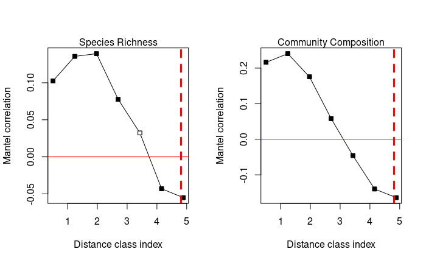

```r
mtext(side=3, 'Community Composition')
abline(v = max_dist, col='red', lwd=3, lty=2)
```

Last point to make is that in this analysis rather than computing 1 p-value we have computed a p-value for each distance class. Therefore, this kind of analysis suffers from the problem of multiple comparisons in which the p-values are not adhering to expected type-I error. Therefore, a correction is applied to each successive test using by default the Holm correction. See the documentation for the `vegan::manel_correlog` function for more information.

## Univariate Modeling

Spatial (and temporal) dependence is a potential problem for inferential statistics because of an assumption of independence of error. However, if sufficient data is available it is often possible to model the spatial component of error and thus “correct” for the lack of independence in a model’s error.

Crawley (2014) provides a straightforward description of these methods and a few examples. Pinheiro and Bates (2000) provide a more detailed discussion with more examples and they provide a useful table and figure (below) that are helpful when deciding which error model to chose from:

This is Table 5.2 from Pinheiro and Bates (2000) in which *s* is the spatial lag and *rho* is the correlation parameter. This is a subset of the models presented in Cressie (1993).

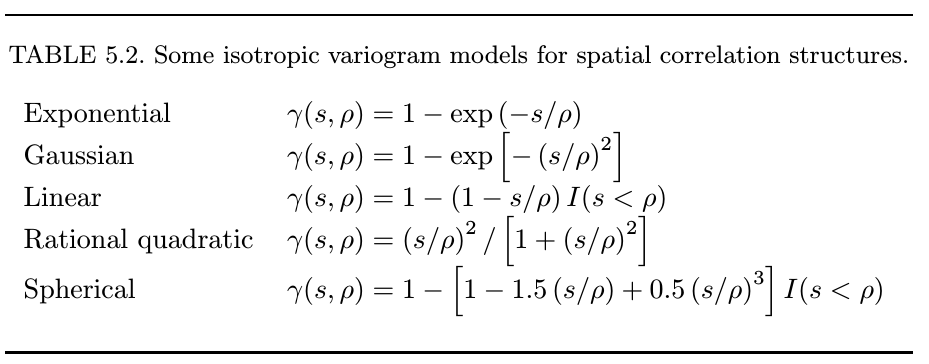

Graphically these models of spatial correlation can be visualized using variogram plots (Figure 5.9 of Pinheiro and Bates 2000):

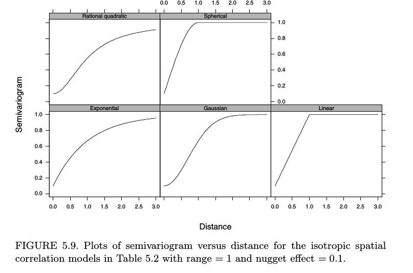

Here is an illustration of these three terms:

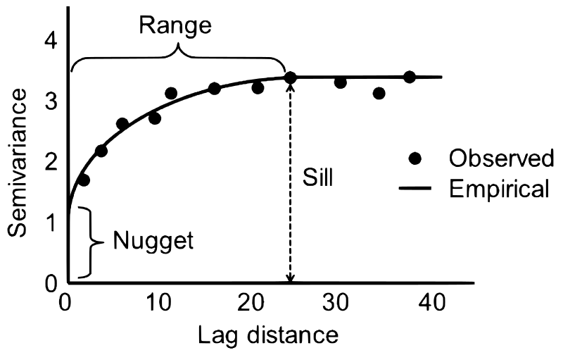

The nugget should in theory be zero because if two samples have no distance between them they should in theory be the same value, but in practice it is often necessary to have a positive valued nugget to accurately describe the spatial corelation function. Note that adding a nugget into a spatial model requires the addition of an extra parameter (i.e., an increase in model complexity).

### Model fitting, interpretation, and comparison

When we carried out ordinary regression we used the formula:

$$y = X\beta + \varepsilon, \qquad
\varepsilon \sim N(0, \sigma^2) \qquad \text{(equ. 1)}$$
Where *y* was a vector we wished to explain variance in (our response variable), *X* was a matrix of explanatory variables we thought influenced *y*, the vector $\beta$ was the vector of intercept and slope coefficients, and $\varepsilon$ was the error or residuals of the model.

As noted above we can consider two sources of non-random spatial structure in *y*. For induced spatial dependence or true gradients we can consider which explanatory variables we include in *X* and if they themselves are spatially structured. In practice, considering induced spatial dependence requires no changes to our modeling structure or philosophy assuming that our samples are truly independent of each other (i.e., sample similarity is only due to having similar conditions in *X* and not because they were simply located near each other).

If however samples are not truly independent and autocorrelation is present in the response variable then we are violating a core assumption of OLS regression that residual error is identically independently distributed (i.i.d). As equ. 1 states the error should be Normally distributed with variance $\sigma^2$ regardless of which samples we are considering. The key problem with ignoring correlations in the error between samples is it means that our sample size is inflated.

##### **Question**

If we are over estimating our sample size will that bias p-values to be smaller or larger?

[Show answer]

```
They will be biased to be smaller because larger samples require a smaller
signal to appear to not be conforming to the null hypothesis. Thus when we
inflate our samples size artifically we are inflating our Type I error and are
more likely to reject the null hypothesis when there is actually no signal.
```

Well what are we going to do about this inflated sample size? The most conservative but often least appealing approach would be to censor your data down to a set of samples that are truly independent. Alternatively you average across non-independent replicates (aka pseudo-replicates). This is often either not feasible or simply unappealing because of the loss of precision and/or power that accompanies a loss of samples. An alternative solution we will examine here is modeling the pattern of autocorrelation in the error of the model using Generalized Linear Models (GLS).

**Note:** GLS models are distinct from General Linear Models (GLM) because GLS models are primarily concerned with modeling the covariance between samples while still adhering to the standard Normal (i.e., Gaussian) distribution assumption for measurement error. In contract, GLMs are typically harnessed when the Normal distribution is not appropriate and we wish to use a different distribution for the error term such as Poisson or Binomial distributions. It is possible to model the correlation structure of the error term in of a GLM but we will not consider that case here.

Let’s start with a simple OLS model for species richness of mites. We’ll examine if substrate density (`SubsDens`) is linearly correlated with richness and if the error of that regression model shows spatial structure thus violating a core assumption of the model.

```r
sr_dat <- data.frame(sr, mite.env, mite.xy)

sr_lm <- gls(sr ~ SubsDens, data=sr_dat)

summary(sr_lm)
```

```
Generalized least squares fit by REML
  Model: sr ~ SubsDens
  Data: sr_dat
```

|  | AIC | BIC | logLik |
| --- | --- | --- | --- |
|  | 422.1378 | 428.7963 | -208.0689 |

```
Coefficients:
```

|  | Value | Std.Error | t-value | p-value |
| --- | --- | --- | --- | --- |
| (Intercept) | 15.587432 | 1.9332242 | 8.062920 | 0.000 |
| SubsDens | -0.012045 | 0.0471129 | -0.255652 | 0.799 |

```
 Correlation:
         (Intr)
SubsDens -0.957

Standardized residuals:
        Min          Q1         Med          Q3         Max
-2.11867624 -0.67441942  0.07126437  0.65748711  2.10544812

Residual standard error: 4.674175
Degrees of freedom: 70 total; 68 residual
```

We can see from the output of that model that substrate density does not seem to correlated to species richness. Let’s examine the residuals of that model using a special kind of plot called a *Variogram* which plots the semivariance of the residuals against spatial lag (i.e., the spatial distance between samples). Although that might sound intimidating we can build our own kind of variogram plot using the `dist` function we used above in the lesson to compute Euclidean distances between entries in a vector or matrix.

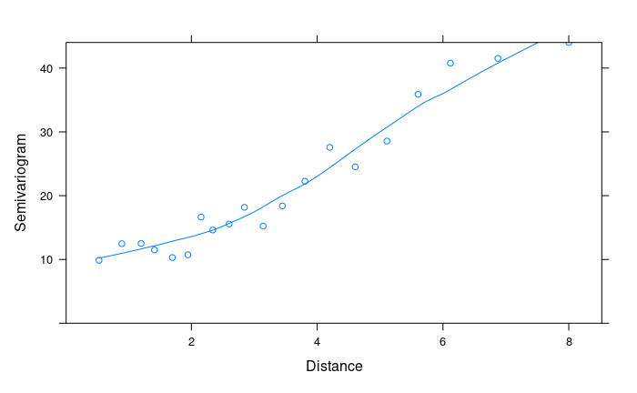

```r
vario_sr <- Variogram(sr_lm, form= ~ x + y, resType = 'response')
# note the default of teh Variogram function is to compute normalized residuals
plot(vario_sr)
```

```r
# compare that to a plot we make on our own
res <- residuals(sr_lm)
res_var <- dist(res)^2 * 0.5
plot(dist(sr_dat[, c('x', 'y')]), res_var)
lines(lowess(dist(sr_dat[, c('x', 'y')]), res_var), col='red', lwd=2)
```

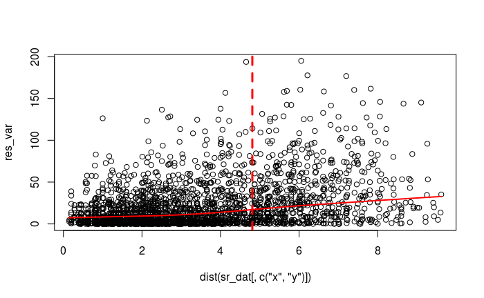

```r
abline(v = max_dist, col='red', lwd=3, lty=2)
```

```r
# they seem to tell a similar story - the error of the model is showing
# positive autocorrelation.
```

The two plots may look a little different only because the Variogram plot has averaged across many pairs of points (the `n.pairs` column of that function’s ouput) to get semivariance estimates for different distance classes. One important point to note is that if you take the weighted average of all the semi-variance estiamtes then that equals the variance of the residuals, here’s a quick demonstration of that:

```r
sum(vario_sr$variog * vario_sr$n.pairs) / sum(vario_sr$n.pairs)
```

```
[1] 21.54601
```

```r
var(res)
```

```
[1] 21.53127
```

Ok, so far we’ve learned that substrate density does not seem to be influencing richness spatially or otherwise and that there still remains autcorrelation in richness. Let’s examine the most common model of spatial (and temporal) autocorrelation: the exponential model also know as Autoregressive 1 model or AR1.

```r
sr_exp <- update(sr_lm, corr=corExp(form=~x + y))
summary(sr_exp)
```

```
Generalized least squares fit by REML
  Model: sr ~ SubsDens
  Data: sr_dat
```

|  | AIC | BIC | logLik |
| --- | --- | --- | --- |
|  | 396.3691 | 405.2471 | -194.1846 |

```
Correlation Structure: Exponential spatial correlation
 Formula: ~x + y
 Parameter estimate(s):
   range
0.652223

Coefficients:
```

|  | Value | Std.Error | t-value | p-value |
| --- | --- | --- | --- | --- |
| (Intercept) | 16.687888 | 1.8686249 | 8.930571 | 0.0000 |
| SubsDens | -0.028673 | 0.0384893 | -0.744963 | 0.4589 |

```
 Correlation:
         (Intr)
SubsDens -0.753

Standardized residuals:
        Min          Q1         Med          Q3         Max
-2.11165790 -0.76670852 -0.03920844  0.59883364  1.95922655

Residual standard error: 4.763405
Degrees of freedom: 70 total; 68 residual
```

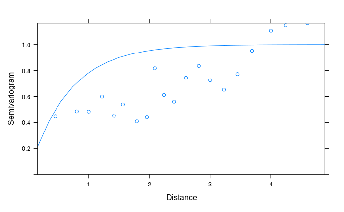

```r
# examine fit of error model to the raw model residuals
# note this function defaults to displaying pearson standardized residuals
# resType='p' or resType='pearson' which have been standardized
plot(Variogram(sr_exp, maxDist = max_dist))
```